# Adv. Microeconometrics Computer Assignment

A. Schmidt

11/19/2020

# 1 - Size distortions

Simulate data from the following model:

$$\begin{align*}
Y &= X \beta + \varepsilon \\
X &= Z\Pi + V
\end{align*}$$
where: * $Y$ and $X$ are $n \times 1$ vectors which contain the endogenous variables; * $Z$ is a $n \times k$ matrix of instruments; * $\varepsilon$ and $V$ are $n \times 1$ vectors that contain disturbances. * The different rows of $\left(\varepsilon\ \vdots\ V\right)$, are independently normally distributed, i.e.,

$$\begin{align*}
\begin{pmatrix}
\varepsilon_i \\
V_i
\end{pmatrix} \sim \mathcal{N}(0, \Sigma), \qquad
\Sigma =
\begin{pmatrix}
1 & \vdots & \rho \\
\rho & & 1
\end{pmatrix}
\end{align*}$$
* $n=100$, $k=10$, $\Pi = a \times e_{10}$ with $e_{10} \in \mathbb{R}^{10}$ whose first element is $1$ and the remaining are equal to zero. * All elements from $Z$ are independently distributed and follows a standard normal distribution. * $a \in \{0.3,.0.25, 0.2, 0.15, 0.1, 0.05, 0 \}$ * $\rho \in \{0.1, 0.2, 0.3, 0.4, 0.5, 0.6, 0.7, 0.8, 0.9, 0.95 \}$

## Item 1

Using a package

Graph for Q1

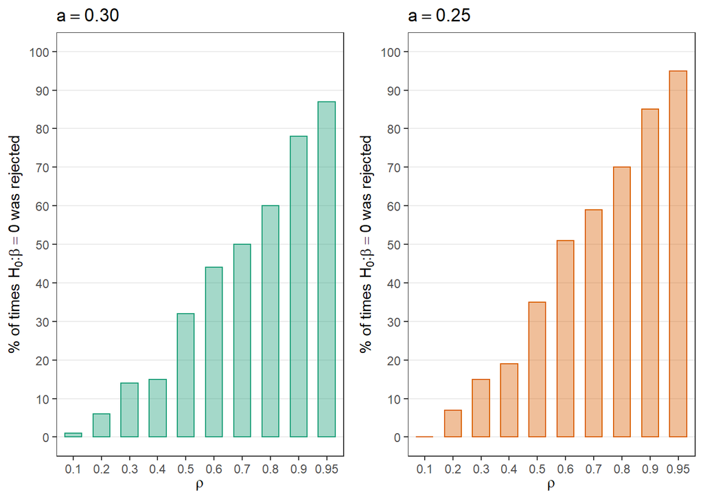

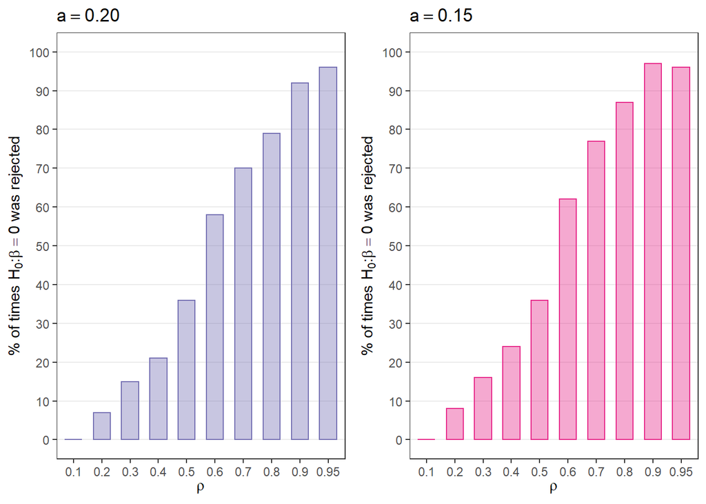

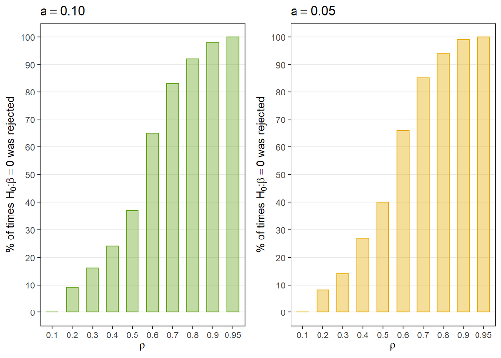

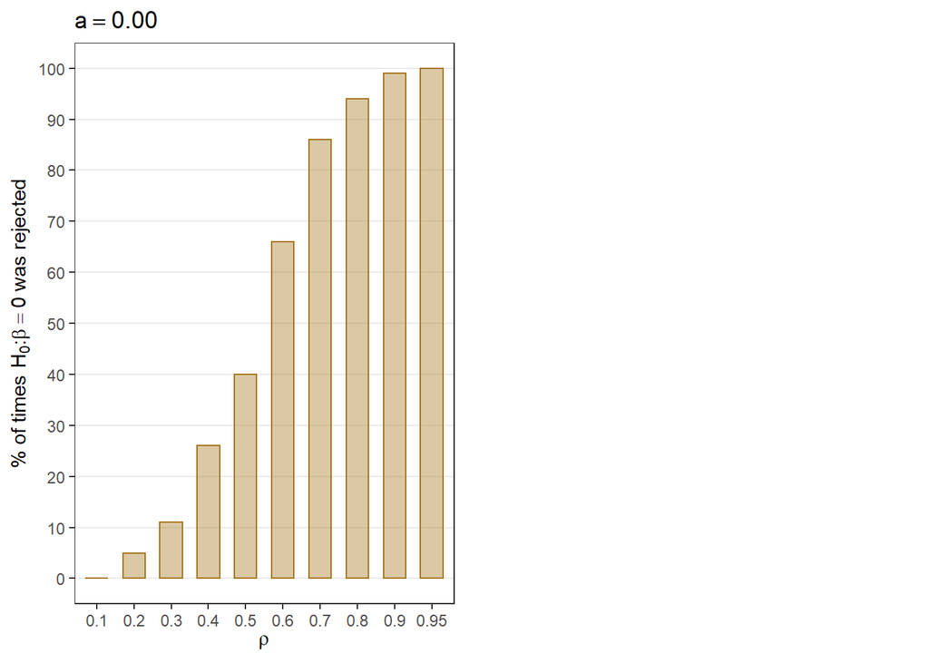

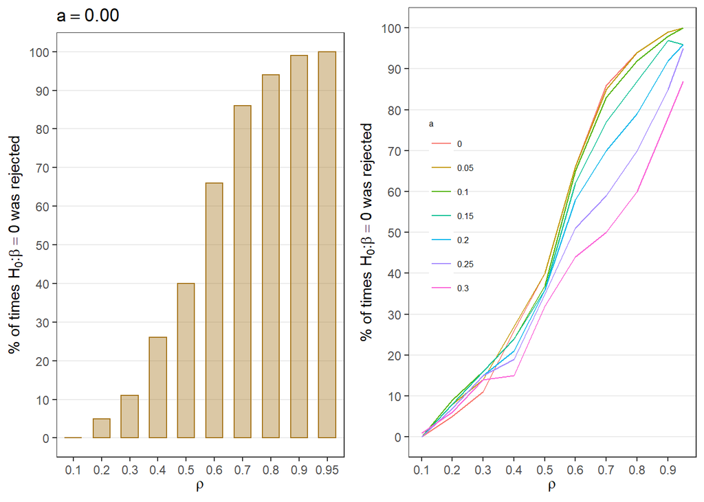

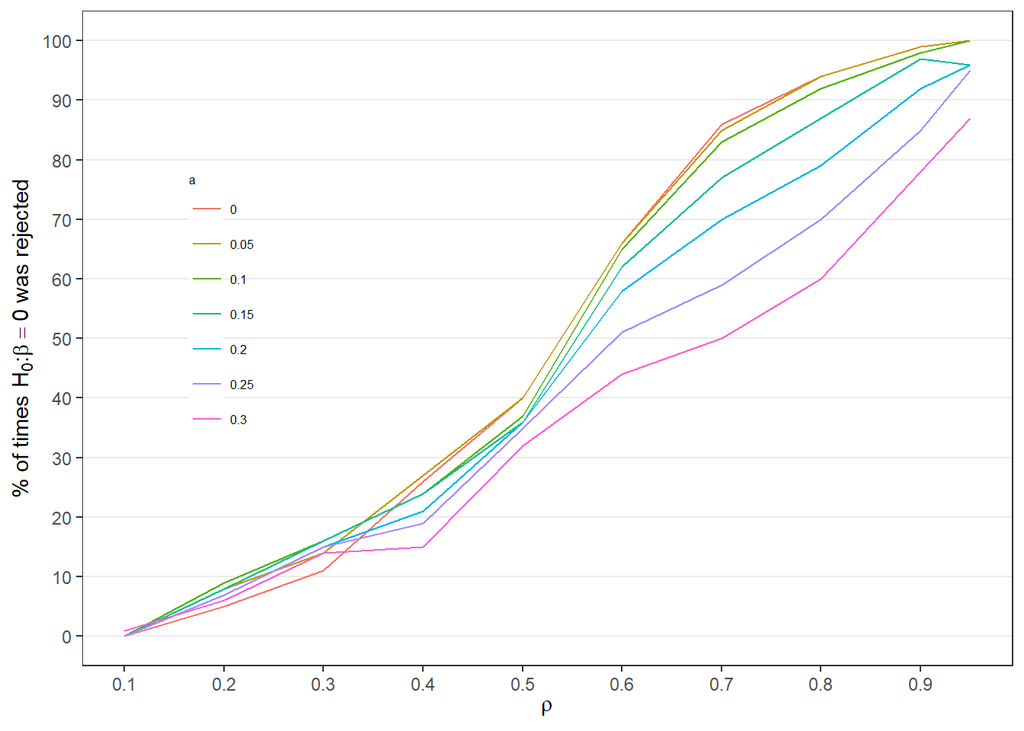

## Question 2

Compute and make a figure of the 95% critical value function of the LR statistic as a function of $r(\beta_0)$ for $k=10$. What can you say about the critical value when $r(\beta_0)=0$ or infinite?

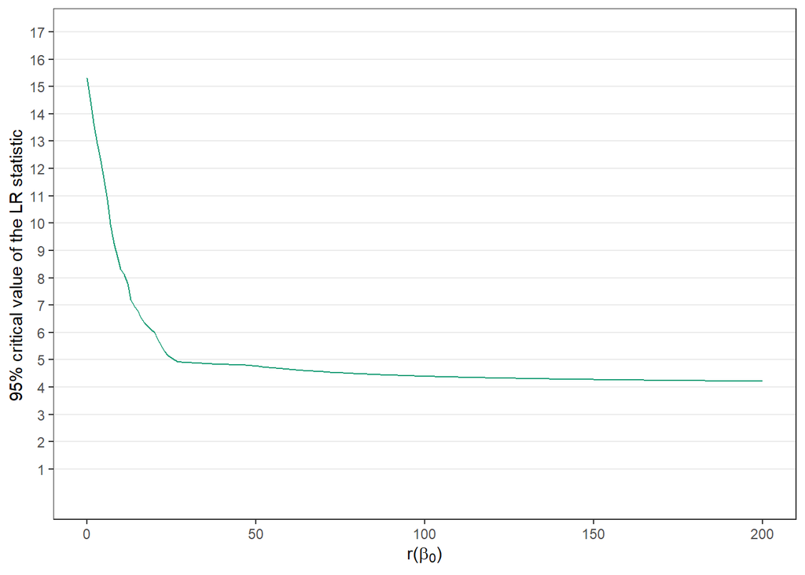

## Question 3

Repeat exercise 1 for the AR, score and LR statistics. What you conclude?

[figure not shown]